# Análisis de la Salinidad en La Guajira

María Isabel Carvajal Londoño

macarvajall@unal.edu.co - Universidad Nacional de Colombia, sede Medellín

Juan Manuel Saldarriaga Velásquez

jsaldarriagav@unal.edu.co - Universidad Nacional de Colombia, sede Medellín

Junio, 2025

# **Introducción**

La salinidad del agua subterránea es un indicador clave de la calidad y aptitud de los recursos hídricos, especialmente en regiones áridas donde la disponibilidad de agua dulce es limitada. En el departamento de La Guajira, la composición de las aguas subterráneas está dominada por cationes como sodio y calcio, y aniones como cloro y magnesio, medidos en PSU (Practical Salinity Units), equivalentes a gramos de sal por litro. La variabilidad espacial de la salinidad en La Guajira obedece, en gran medida, a procesos hidrológicos y geológicos locales: intrusión marina en zonas costeras, afloramiento de acuíferos en áreas elevadas e influencia de depósitos fluviales en las riberas de ríos como el Ranchería y el Cesar.

Los inventarios realizados muestran que en la Alta Guajira los valores oscilan entre 0.248 y 40.360 PSU (media 3.553 PSU), con las conductividades más bajas asociadas a manantiales de estructura rocosa y las más altas a captaciones próximas a la costa, reflejando intrusión marina. En la Media Guajira, los registros varían de 0.089 a 59.8 PSU (media 1.785 PSU), donde los puntos con salinidad mínima se ubican en depósitos aluviales recientes y los máximos en la llanura aluvial del Ranchería. Aquí, predominan las aguas salobres, con pocos aljibes catalogados como marinos. Por último, en la Baja Guajira, la salinidad va de 0.063 a 23.47 PSU (media 0.694 PSU), presentando la proporción más alta de aguas dulces por la influencia de cauces fluviales y abanicos aluviales. A pesar de estas diferencias, la clasificación media de las tres zonas se sitúa en el rango de aguas salobres.

En particular, la Guajira produce el 70% del cloruro de sodio a nivel nacional (Banco de la República, s.f), lo cual, hace imperativo su análisis.

# **Planteamiento del problema**

El departamento de La Guajira, ubicado en el extremo norte de Colombia, enfrenta condiciones climáticas extremas caracterizadas por precipitaciones escasas, alta radiación solar y una prolongada estación seca (IDEAM, 2021). Estas condiciones, sumadas a la sobreexplotación de recursos hídricos y a la creciente presión sobre acuíferos y cuerpos de agua superficiales, han generado un incremento en los niveles de salinidad del suelo y del agua en diversas zonas del territorio. La salinidad, entendida como la concentración de sales solubles en el agua o en el suelo, constituye un factor crítico para la sostenibilidad ambiental, la seguridad alimentaria y la salud pública en esta región (FAO, 2015; Qadir et al., 2014).

Desde el punto de vista agrícola, la acumulación de sales en el suelo reduce la productividad de los cultivos y limita las posibilidades de diversificación agrícola, afectando especialmente a las comunidades indígenas y rurales cuya economía depende directamente de la tierra (Qadir et al., 2014). A nivel hídrico, el aumento de la salinidad compromete la potabilidad del agua, exacerba los problemas de acceso al recurso y genera riesgos sanitarios en las zonas más vulnerables (González & Rudas, 2019). En este sentido, el Servicio Geológico Colombiano (SGC) ha señalado la urgencia de estudiar el potencial de las aguas subterráneas del departamento y su calidad, con el fin de evaluar si son aprovechables frente a la crisis hídrica (El Espectador, 2024).

Por estas razones, estudiar la salinidad en La Guajira no solo es relevante desde una perspectiva ambiental, sino también desde un enfoque social y de política pública. Sin embargo, el monitoreo de la salinidad se enfrenta a limitaciones por la escasez de estaciones de medición y la dispersión geográfica de los puntos de muestreo. En este contexto, las herramientas de análisis espacial y geoestadístico, como el kriging, se vuelven fundamentales para estimar la salinidad en áreas no muestreadas y generar mapas de riesgo a partir de datos puntuales.

# **Objetivo**

Desarrollar un modelo geoestadístico para mapear la salinidad de las aguas subterráneas en La Guajira.

# **Motivación**

En un contexto donde la escasez de agua dulce se agrava debido al cambio climático, el uso intensivo de fuentes subterráneas y la falta de infraestructura hídrica, comprender la distribución espacial de la salinidad en los acuíferos de La Guajira se vuelve una prioridad estratégica. La salinización de aguas subterráneas no solo limita la disponibilidad de agua para consumo humano, sino que también reduce la capacidad de respuesta de los sistemas locales ante eventos de sequía prolongada, afectando de forma desproporcionada a comunidades vulnerables y rurales (ANLA, 2020).

El análisis espacial de la salinidad permite identificar zonas críticas donde la calidad del recurso hídrico ha sido comprometida, ya sea por procesos naturales de intrusión salina, comunes en zonas costeras, o por actividades antropogénicas como la sobreexplotación de pozos y el uso inadecuado de prácticas agrícolas.

# **¿Qué se pretende estudiar en esta primera etapa?**

¿Cómo se distribuye espacialmente la salinidad en el departamento de La Guajira y cuáles son las zonas con mayor y menor riesgo de salinización según los modelos geoestadísticos?

# **Análisis Estructural Geoestadístico**

La base de datos consta de 1.673 observaciones y 33 variables. Para esta etapa focalizaremos el análisis en las coordenadas espaciales (X, Y) y en la variable de respuesta Z, que registra los niveles de salinidad. Antes de avanzar con la modelación geoestadística, se realizó una exploración preliminar que incluyó la transofrmación del sistema de coordenadas a UTM, zona 18N.

A continuación, se muestra el encabezado de los datos:

Encabezado de los datos

| OBJECTID | ID_TOTAL | ID_PROYECT | Plancha | No_Consecu | Tipo_de_Ca | Sitio | Origen | X | Y | Uso_del_Su | Condición | Prof_Pozo | Tipo_de_Ni | Método_de | Prof_Seco | Prof_Húme | Observacio | pH_seco | Cond_Seco | T_Seco | STD_seco | Sal_seco | sigsonia__ | pH_Humedo | Cond_seco1 | T_seco1 | STD_Seco1 | Sal_seco_1 | sigsonia_1 | … |
| --- | --- | --- | --- | --- | --- | --- | --- | --- | --- | --- | --- | --- | --- | --- | --- | --- | --- | --- | --- | --- | --- | --- | --- | --- | --- | --- | --- | --- | --- | --- |
| 1 | 1 | 1 | NA | 1 | Pozo | Siapana | Central | 1299676 | 1827468 | NA | NA | NA | NA | NA | NA | NA | NA | 7.50 | 3060 | 31.2 | 1500.7357 | 1.68300 | 0 | 0.00 | 0 | 0.0 | NA | NA | NA | … |
| 2 | 2 | 2 | NA | 2 | Aljibe | Iruapaa | Central | 1299086 | 1828797 | NA | NA | NA | NA | NA | NA | NA | NA | 7.12 | 1585 | 31.4 | 777.3418 | 0.87175 | 0 | 7.14 | 1620 | 30.3 | NA | NA | NA | … |
| 3 | 3 | 3 | NA | 3 | Aljibe | Kashinas | Central | 1298372 | 1829001 | NA | NA | NA | NA | NA | NA | NA | NA | 7.07 | 995 | 32.7 | 487.9843 | 0.54725 | 0 | 7.39 | 917 | 28.8 | NA | NA | NA | … |
| 4 | 4 | 4 | NA | 4 | Aljibe | Polujalii | Central | 1298004 | 1829239 | NA | NA | NA | NA | NA | NA | NA | NA | 7.37 | 1339 | 33.3 | 656.6945 | 0.73645 | 0 | 7.42 | 1394 | 30.1 | NA | NA | NA | … |
| 5 | 5 | 5 | NA | 5 | Pozo | Siapana | Central | 1299536 | 1826712 | NA | NA | NA | NA | NA | NA | NA | NA | 7.69 | 1553 | 0.0 | 761.6479 | 0.85415 | 0 | 7.64 | 1611 | 34.4 | NA | NA | NA | … |
| 6 | 6 | 6 | NA | 1 | Manantial | Witpa | Central | 1289335 | 1822647 | NA | NA | NA | NA | NA | NA | NA | NA | 7.29 | 3110 | 30.1 | 1525.2575 | 1.71050 | 0 | 7.47 | 3100 | 30.7 | NA | NA | NA | … |

## Análisis Descriptivo

Para familiarizar al lector con la distribución espacial y cuantitativa de la salinidad en La Guajira, se ha realizado un análisis descriptivo de los datos.

Resumen Estadístico de SAL

| Estadístico | SAL |
| --- | --- |
| Min. | 0.063 |
| 1st Qu. | 0.504 |
| Median | 0.880 |
| Mean | 1.722 |
| 3rd Qu. | 1.782 |
| Max. | 59.800 |

La distribución de SAL muestra un fuerte sesgo positivo: la media (1.722) casi duplica la mediana (0.880), impulsada por un valor atípico extremo (59.800) lo cual puede dar pie aplicar una transformaciones (por ejemplo, logarítmica) o utilizar medidas robustas para mitigar el impacto de esos valores extremos.

Asimismo, con el fin de observar la cobertura del área de estudio se presenta el siguiente gráfico:

[interactive chart not shown]

De igual manera, para visualizar la distribución espacial de la salinidad en La Guajira, el siguiente gráfico emplea una escala de color que va de azul/verde en las zonas de menor altitud (cercanas a la Sierra Nevada de Santa Marta), donde el aporte de agua dulce diluye la salinidad, hasta tonos cálidos (amarillo, magenta y rojo) en las áreas elevadas, donde la mayor evaporación y la limitada escorrentía concentran las sales, evidenciando así un claro gradiente altitudinal en los niveles de sal que será de interés considerar en los análisis posteriores.

[interactive chart not shown]

Finalmente, se incluye un diagrama de dispersión de los puntos con sus coordenadas UTM y su contorno, de manera que el lector pueda verificar visualmente el uso correcto de este sistema de referencia espacial.

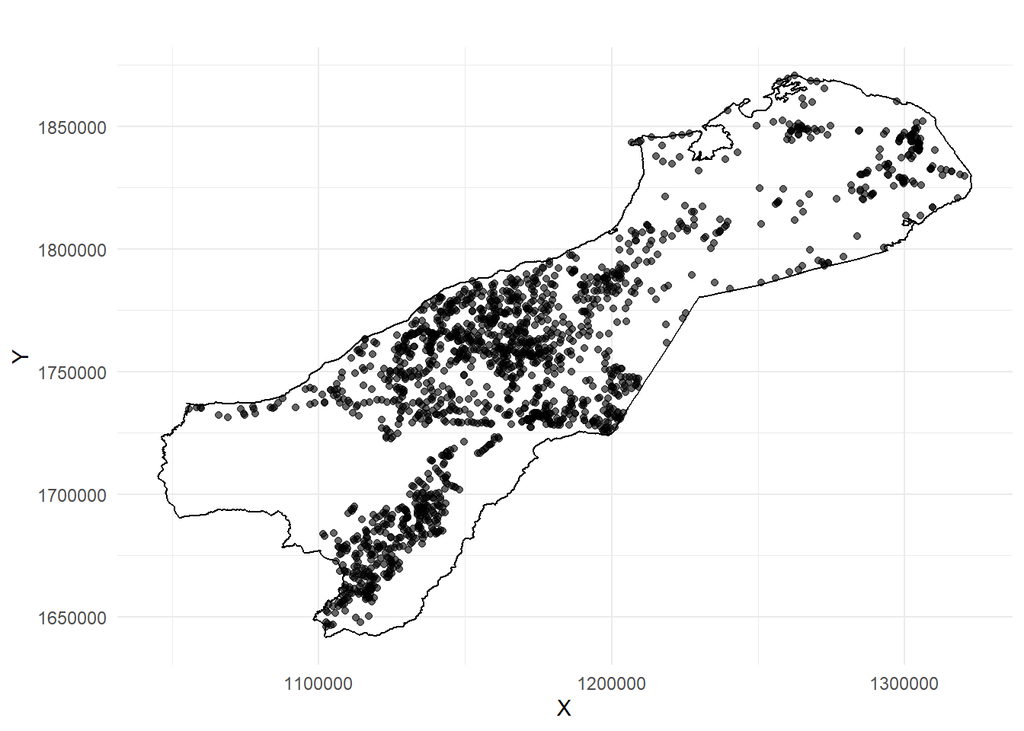

## Análisis Estructural

A continuación se calcula la matriz de distancias espaciales (en UTM) y la disimilitud al cuadrado de la salinidad y se presenta el semivariograma cloud:

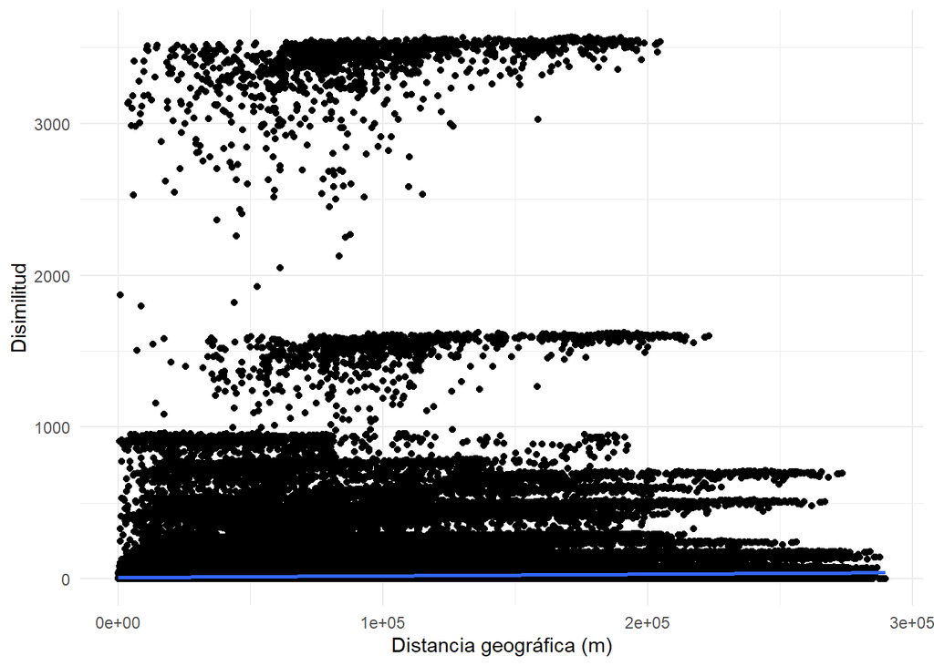

Debido a esta tendencia, se plantea el test de Mantel para confirmar las hipótesis anteriormente dichas:

Sea el siguiente contraste de hipótesis espacial:
$$\begin{cases}
H_{0}: & \text{Hay aleatoriedad espacial},\\
H_{1}: & \text{Hay estructura espacial}.
\end{cases}$$

Test de Mantel

| Mantel..r. | p.valor |
| --- | --- |
| 0.04806 | 0.019 |

Test de Mantel con permutaciones

| Mantel..r. | p.valor | N..Repeticiones |
| --- | --- | --- |
| 0.04806 | 0.023 | 999 |

Tras calcular el estadístico de Mantel y obtener p-valores menores a $\alpha=0.05$ tanto en la prueba simple (p=0.019) como en la de 999 permutaciones (p=0.023), se rechaza la hipótesis nula de aleatoriedad espacial, validando la presencia de autocorrelación en los datos de salinidad y justificando el uso posterior de modelos geoestadísticos (variograma teórico y kriging) para la interpolación en toda la región de La Guajira.

Asimismo, se plantea el test de normalidad:

$$\begin{cases}
H_{0}: & \text{Hay Normalidad en los datos},\\
H_{1}: & \text{No hay normalidad en los datos}.
\end{cases}$$

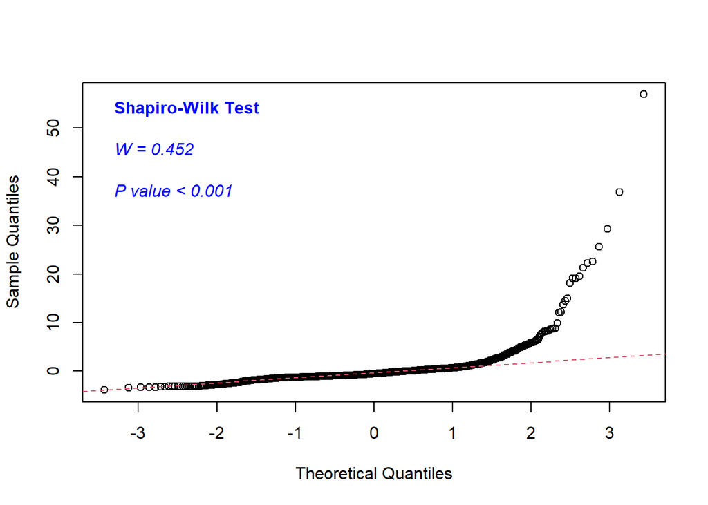

Con un nivel de significancia $\alpha = 0.05$, la prueba rechaza la hipótesis nula de normalidad, evidenciando que los datos no siguen una distribución normal. Sin embargo, esto no compromete el análisis, puesto que podemos recurrir a estimadores robustos o aplicar transformaciones adecuadas; lo esencial es garantizar el cumplimiento de la estructura espacial subyacente para llevar a cabo una interpolación kriging válida.

## Visualización Exploratoria de la Salinidad

A continuación se presenta un conjunto de gráficos descriptivos que permiten examinar la distribución espacial y marginal de los niveles de salinidad registrados en La Guajira.

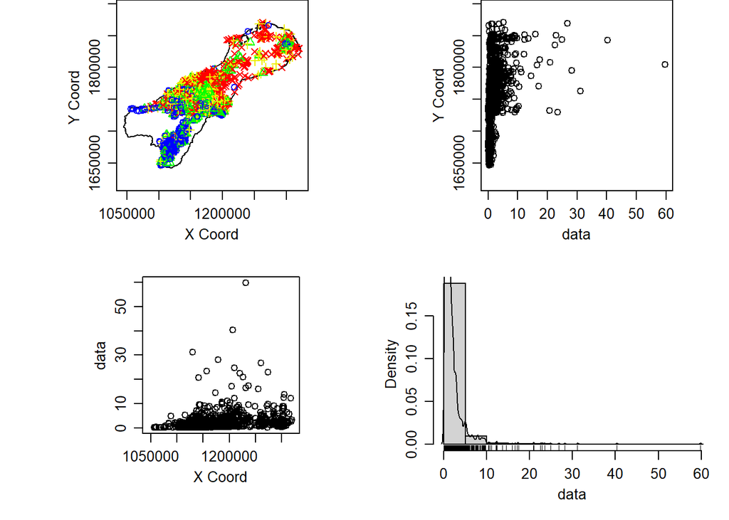

Asimismo, debido a que en el gráfico anterior no se observa una tendencia clara, el histograma permite identificar ciertas mejoras en términos de asimetría. Sin embargo, en el gráfico mostrado a continuación persisten agrupamientos en zonas específicas. En los paneles derecho e inferior izquierdo (residuos vs. coordenadas Y y X, respectivamente) no se evidencia un patrón sistemático a lo largo de ninguno de los ejes, lo cual es deseable. No obstante, el histograma de densidad continúa mostrando una asimetría positiva con una cola larga hacia la derecha, lo que indica la conveniencia de utilizar estimadores robustos al modelar la estructura de autocorrelación espacial.

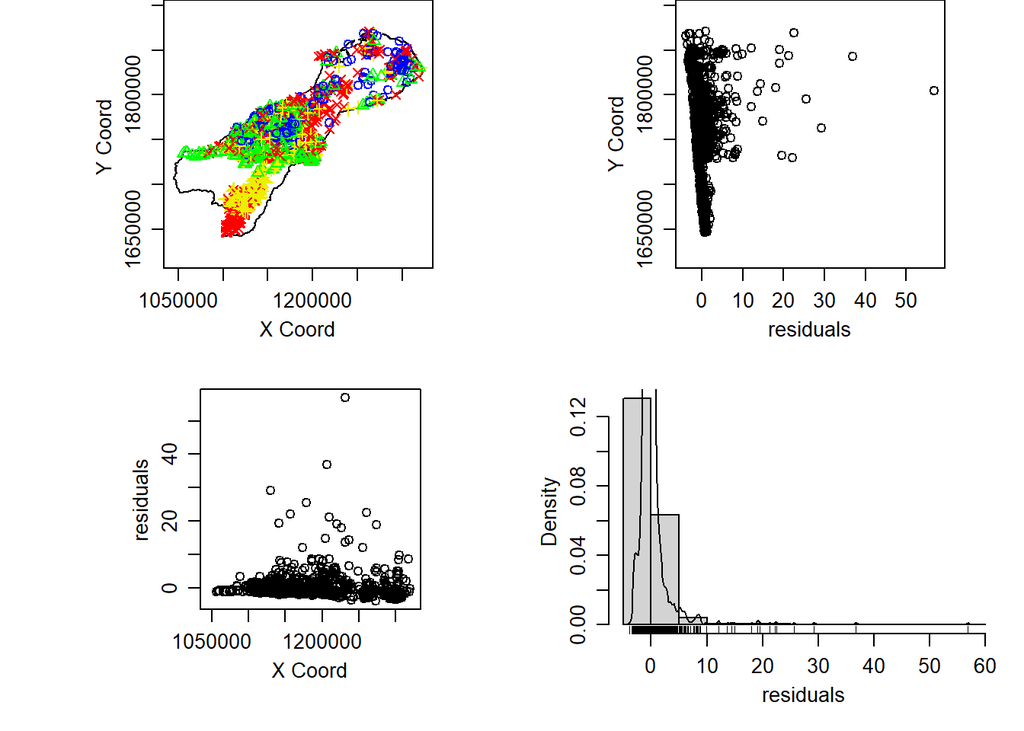

# Semivariogramas

## Semivariograma tipo Bin (con max.dist=144892.119)

```
## variog: computing omnidirectional variogram
```

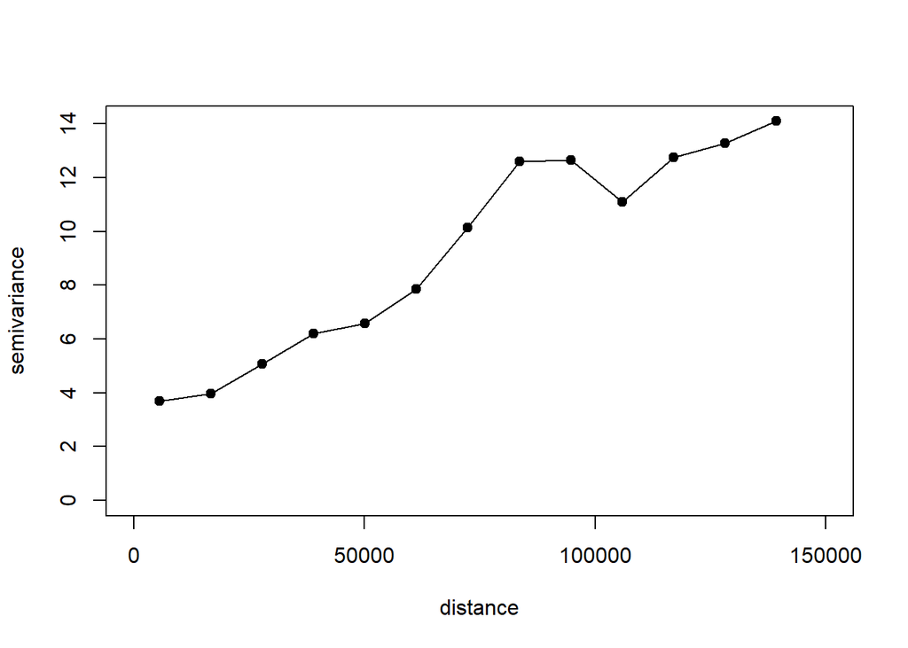

## Semivariogramas con envolventes

Por último, se presentan los semivariogramasde la variable de salinidad observada en La Guajira, acompañados de sus respectivas envolventes para el estimador clásico y robusto respectivamente.

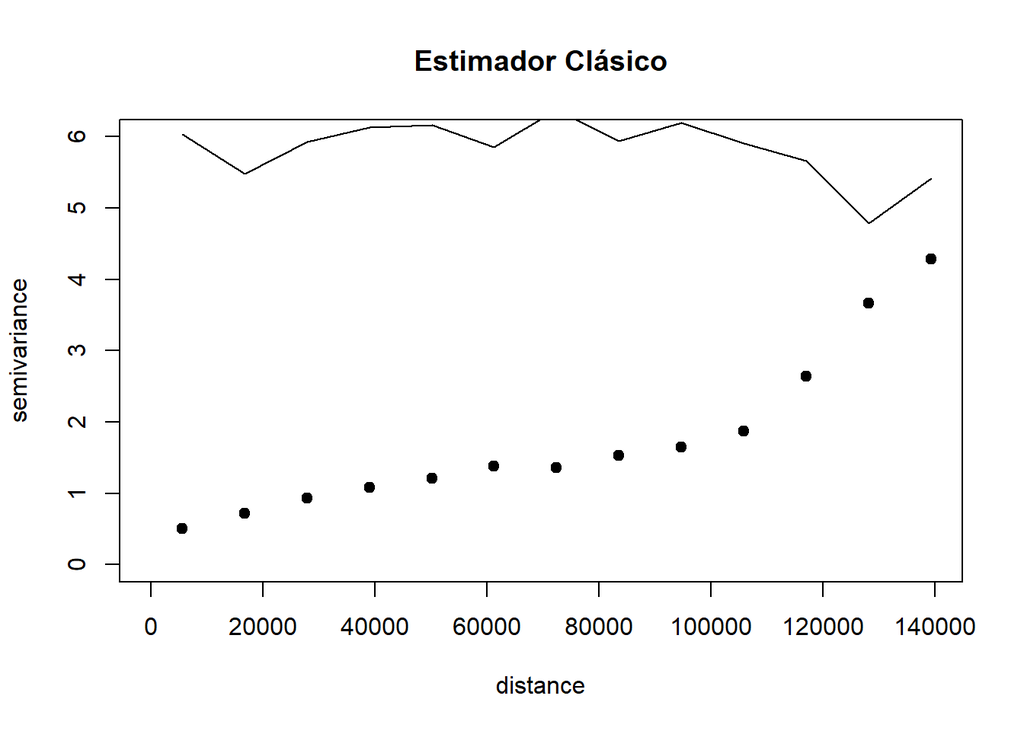

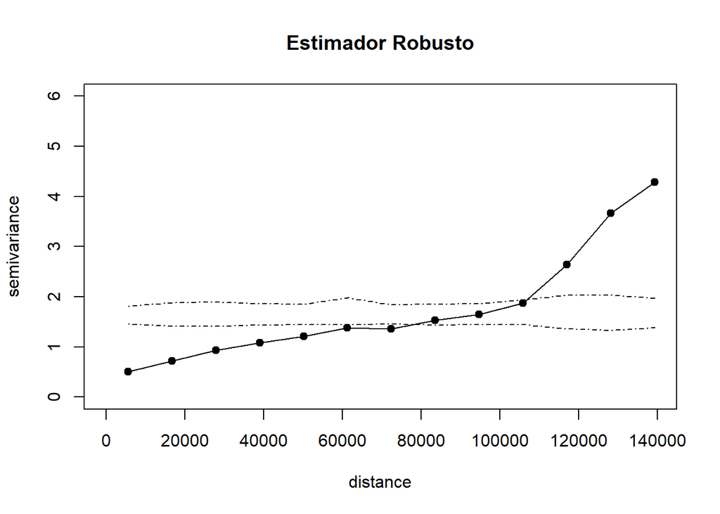

```
## Test of spatial independence: p =  0.002
```

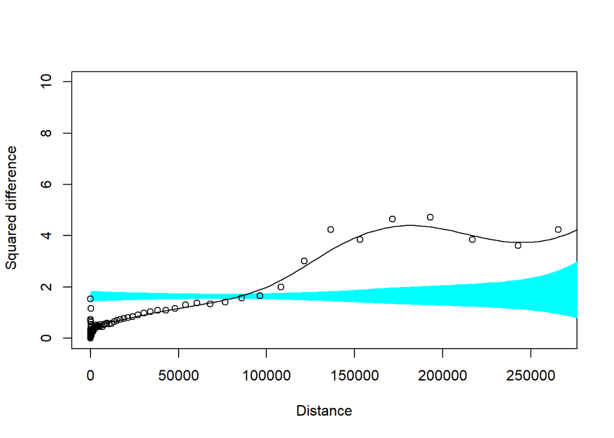

Por último, para corroborar la presencia de estructura espacial se construyó el semivariograma. La banda turquesa representa un intervalo de confianza obtenido por simulación bajo el supuesto de independencia espacial; que buena parte de los puntos empíricos quede sistemáticamente por encima de esa banda a partir de distancias intermedias evidencia un claro rechazo de la independencia y confirma la existencia de dependencia espacial o estructura en los datos.

# Estimación de los parámetros de la función de covarianza

El cálculo del rango práctico —distancia a la cual la correlación residual cae a $0.05$— resultó en $260\,300.4$ unidades, lo que implica que las observaciones permanecen espacialmente correlacionadas hasta aproximadamente $260$,km. Más allá de ese umbral, la semivarianza se estabiliza alrededor del sill, reflejando la atenuación de la dependencia espacial. El valor minimizado de la suma de cuadrados ponderados ($1\,241\,792$) respalda la solidez del ajuste: a pesar de cierta dispersión en puntos intermedios, el modelo Matern con $\kappa = 0.5$ describe fielmente la variabilidad espacial observada.

```
## variofit: covariance model used is matern
## variofit: weights used: npairs
## variofit: minimisation function used: optim
```

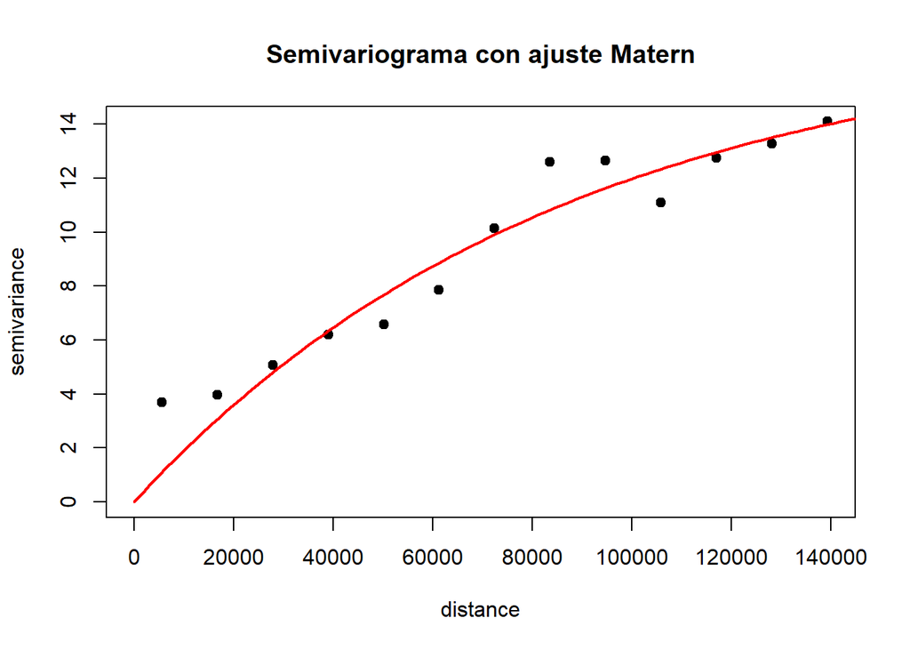

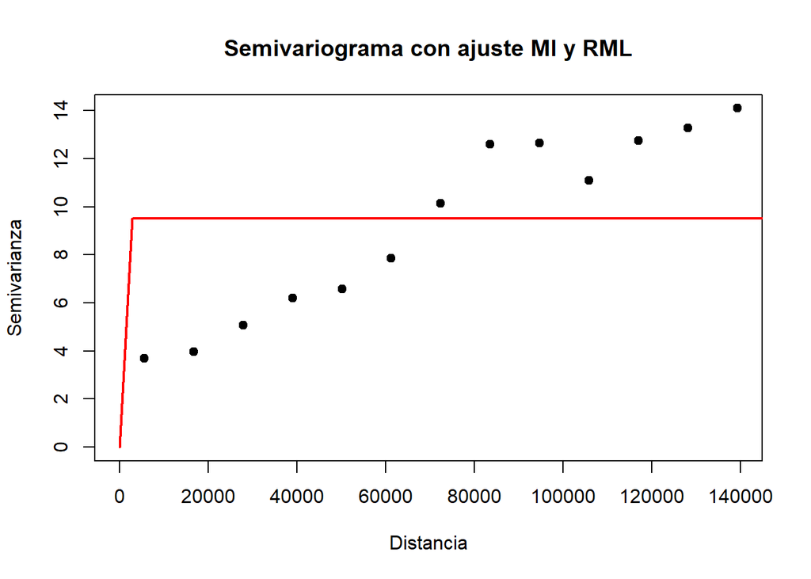

# Predicción Espacial

Con el objetivo de realizar la interpolación espacial, se generó una malla regular compuesta por 10.000 puntos distribuidos sobre el territorio del departamento de La Guajira. Esta malla define las ubicaciones en las cuales se llevará a cabo la predicción mediante kriging. A continuación, se presenta la visualización de dicha malla superpuesta sobre el contorno geográfico del área de estudio.

```
## Rango empírico ≃ 144892.1 metros
```

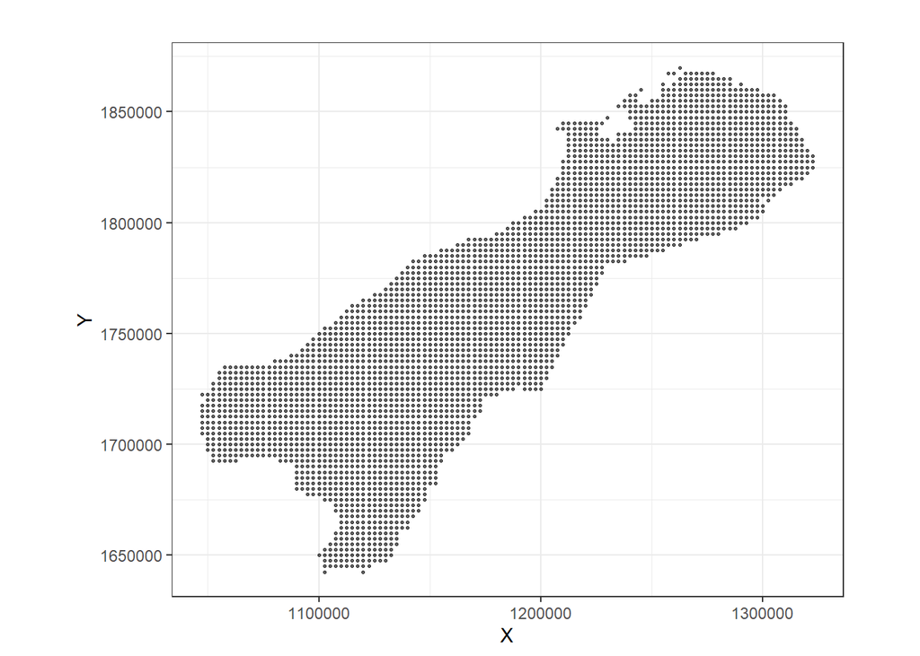

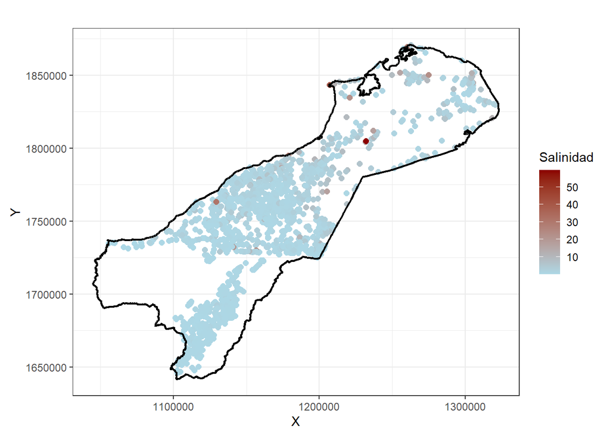

# Kriging

## Ordinario

El kriging ordinario es una técnica de interpolación espacial que asume una tendencia constante en todo el dominio de estudio. Bajo este enfoque, se considera que la media del proceso es desconocida pero uniforme, por lo que el modelo se centra únicamente en capturar la estructura de dependencia espacial a través del semivariograma. Esta metodología resulta adecuada cuando no se evidencian variaciones sistemáticas en la tendencia de los datos a lo largo del territorio, es decir, cuando no hay indicios de gradientes espaciales marcados. Por tanto, el kriging ordinario es especialmente útil en contextos donde se espera que la media del fenómeno sea homogénea en todo el área de estudio.

Usando los parámetros estimados a partir del semivariograma experimental (bin2), se ajustó un modelo ordinario:

```
## [using ordinary kriging]
```

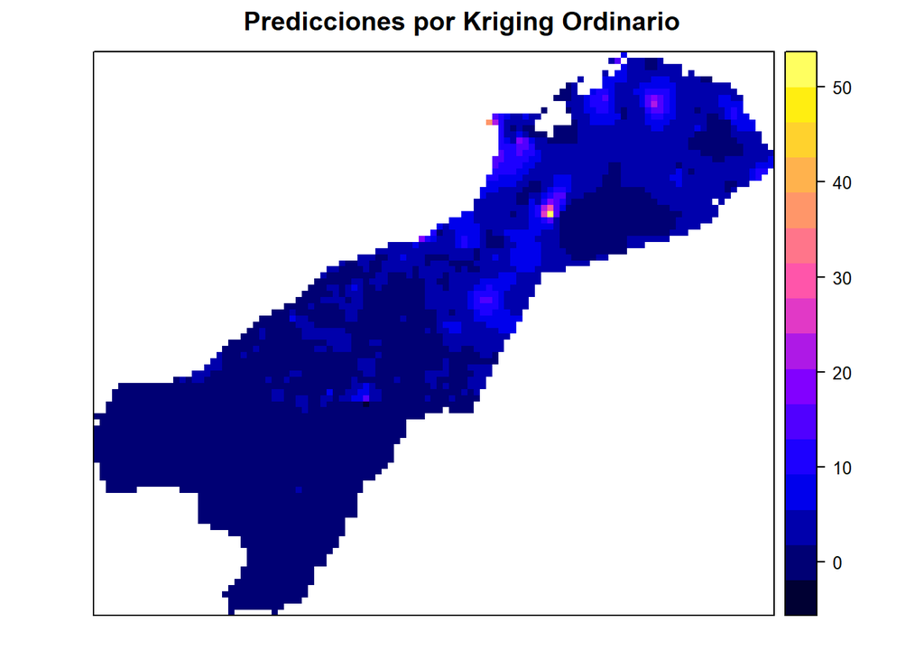

El mapa de predicciones generado por Kriging Ordinario muestra que la mayor parte del territorio presenta valores de salinidad muy bajos, mientras que las concentraciones más altas se localizan en focos muy puntuales del norte y centro. Esta distribución refuerza la idea de no estacionariedad en la media, ya que las zonas con valores elevados no se explican por una variación aleatoria alrededor de una media constante. Además, el modelo parece suavizar excesivamente fuera de las zonas densamente muestreadas, lo que sugiere que el supuesto de media constante puede no ser adecuado, y que un kriging universal o con covariables podría ofrecer una representación más realista del fenómeno.

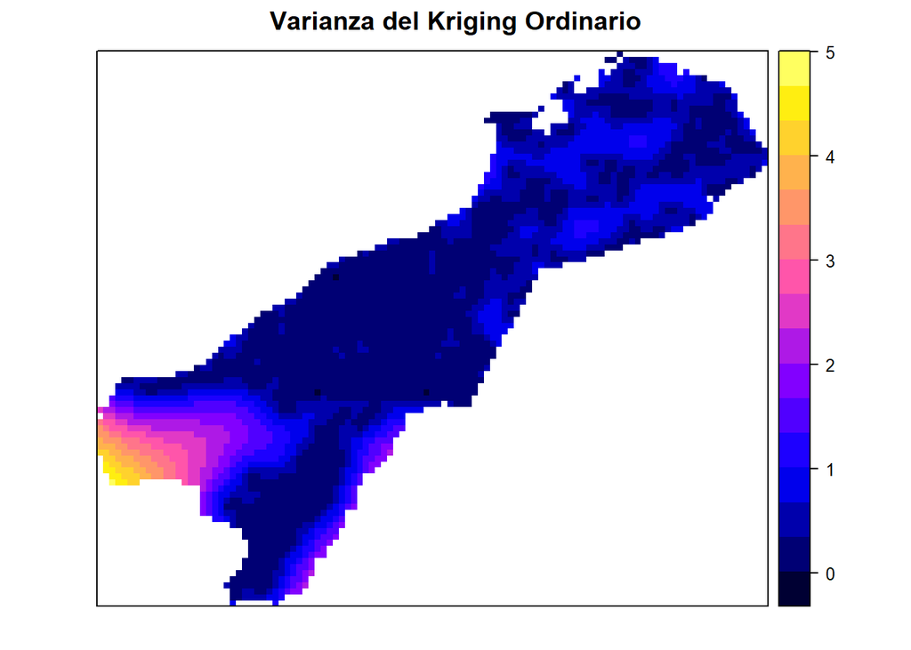

El mapa de varianza del Kriging Ordinario muestra que la incertidumbre en las predicciones es mínima en las zonas donde hay mayor densidad de datos (centro y norte), y se incrementa notablemente hacia el suroccidente, especialmente en áreas periféricas con poca o nula información. Esto es esperable, ya que el kriging asigna mayor varianza a las predicciones lejanas a los puntos muestreados. Esta distribución indica la necesidad de fortalecer el muestreo en zonas con alta incertidumbre para mejorar la precisión del modelo.

Si bien las predicciones reproducen adecuadamente los valores elevados observados en el norte del departamento, el modelo tiende a suavizar excesivamente otras zonas, especialmente en presencia de gradientes espaciales, debido a que en este ejercicio la media no es constante. Esto genera sesgos en las estimaciones y una pérdida de estructura real en los datos. Por su parte, el mapa de varianza refleja mayor incertidumbre en áreas poco muestreadas, como el suroeste, mientras que en zonas densamente observadas la incertidumbre es prácticamente nula. Dado que el supuesto de media constante no se cumple en este caso, el uso de kriging ordinario resulta inadecuado, por lo que se recomienda avanzar hacia un modelo de kriging universal que permita capturar explícitamente la tendencia espacial.

## Universal

A diferencia del kriging ordinario, el kriging universal permite incorporar una tendencia espacial no constante, lo que lo convierte en una herramienta más flexible y adecuada para fenómenos que exhiben variaciones sistemáticas a lo largo del espacio. Esta flexibilidad se logra mediante la inclusión de un modelo determinista en el componente de tendencia, representado aquí por funciones de las coordenadas espaciales (en este caso, $X$ y $Y$), lo que permite capturar gradientes geográficos o estructuras más complejas en los datos. En este caso, utilizando los parámetros estimados a partir del semivariograma residual, se ajustó un modelo exponencial que sirvió de base para realizar la interpolación mediante kriging universal:

```
## [using universal kriging]
```

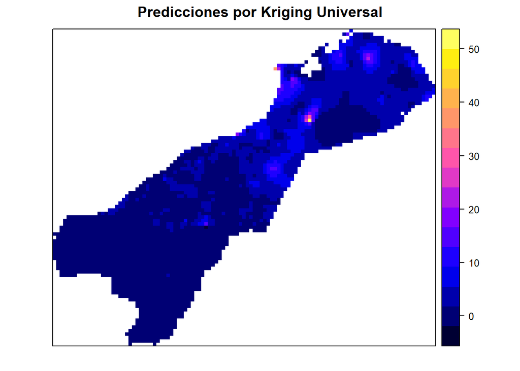

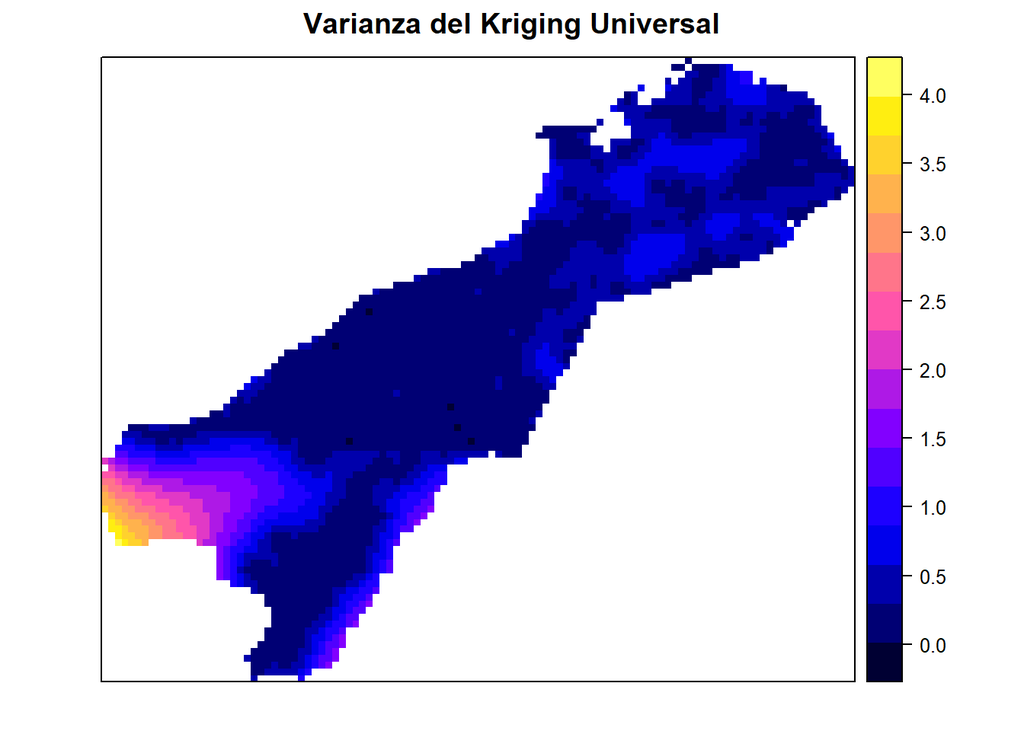

# Validación Cruzada

Finalmente, se presenta la validación cruzada del modelo de kriging universal, implementada con 10 particiones (nfold = 10), con el fin de evaluar su capacidad predictiva y el ajuste general del modelo.

Métricas de Validación Cruzada – Kriging

| Métrica | Valor | Interpretación |
| --- | --- | --- |
| RMSE (Root Mean Square Error) | 2.94 | Promedio del error cuadrático; mide desviación respecto al valor real |
| MAE (Mean Absolute Error) | 1.12 | Promedio del error absoluto; más robusto ante valores atípicos |
| Varianza de los datos observados | 9.49 | Indica dispersión de los valores reales en el conjunto |
| Desviación estándar | 3.08 | Promedio de la distancia a la media; escala de la variable |

Nota:  
Fuente: Elaboración propia con resultados de validación cruzada del modelo de kriging.

Asimismo, se presenta el gráfico que compara los valores observados con los errores de predicción, con el fin de visualizar el comportamiento del modelo frente a distintas magnitudes de la variable:

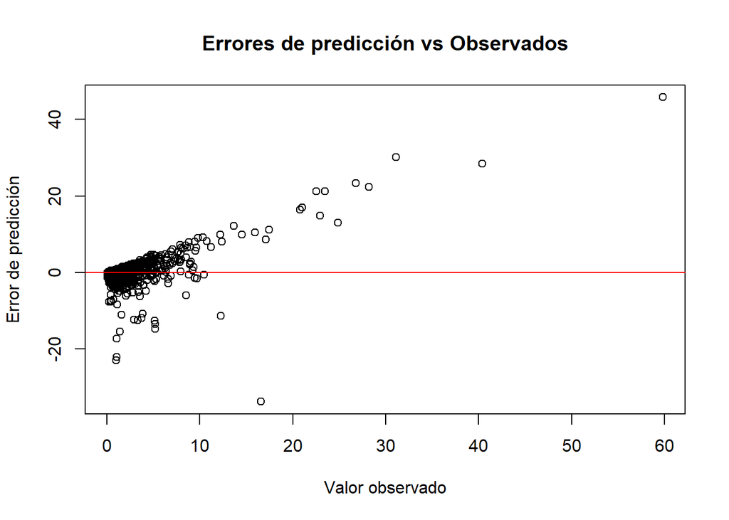

El gráfico de errores de predicción frente a los valores observados, derivado de la validación cruzada del modelo de kriging universal, evidencia un buen desempeño predictivo en rangos bajos y moderados de salinidad: la mayoría de los errores se concentran alrededor de cero cuando los valores observados son inferiores a 15, lo que sugiere una adecuada capacidad del modelo para capturar la estructura espacial predominante. No obstante, se observa una dispersión creciente en los errores a medida que aumentan los valores observados, con algunos puntos extremos que revelan sobreestimaciones o subestimaciones significativas. Esto indica que el modelo presenta limitaciones para predecir correctamente en las colas superiores de la distribución, posiblemente debido a la escasez de datos en esos rangos o a la presencia de valores atípicos que afectan el ajuste local.

# Conclusiones

Los resultados obtenidos a lo largo de este informe confirman de manera contundente la existencia de autocorrelación espacial significativa en los datos de salinidad registrados en La Guajira. La prueba de Mantel, tanto en su versión simple como en la versión con permutaciones, arrojó p-valores inferiores al umbral de significancia ($\alpha = 0{,}05$), permitiendo rechazar la hipótesis nula de aleatoriedad espacial. Esto justifica plenamente el uso de herramientas geoestadísticas para profundizar el análisis del fenómeno, como el ajuste de semivariogramas y la interpolación mediante kriging.

Desde una perspectiva exploratoria, se evidenció una fuerte asimetría positiva en la distribución de los datos, lo cual motivó la aplicación de estimadores robustos que ofrecieran una representación más precisa de la estructura espacial, evitando el sesgo que podría inducir la presencia de valores extremos.

# Referencias

- Autoridad Nacional de Licencias Ambientales. (2020). Reporte de análisis regional: Actualización del reporte de alertas de análisis regional de la zona hidrográfica Caribe – Guajira. ANLA.
- Banco de la República (2003). Salinas de Manaure: Tradición Wayuú y modernización (Documento de Trabajo sobre Economía Regional y Urbana No. 35). Banco de la República. https://repositorio.banrep.gov.co/bitstream/20.500.12134/3189/1/dtser_35.pdf
- Instituto de Hidrología, Meteorología y Estudios Ambientales (IDEAM). (2021). Boletín Agroclimático Nacional - Región Caribe.
- FAO. (2015). Status of the World’s Soil Resources (SWSR) – Main Report. Food and Agriculture Organization of the United Nations. https://www.fao.org/3/i5199e/i5199e.pdf
- González, J., & Rudas, A. (2019). La gestión del agua en territorios indígenas de La Guajira: retos en un contexto de escasez hídrica. Revista de Estudios Sociales, 68, 16–31. https://doi.org/10.7440/res68.2019.02
- Qadir, M., Quillérou, E., Nangia, V., Murtaza, G., Singh, M., Thomas, R. J., … & Noble, A. D. (2014). Economics of salt-induced land degradation and restoration. Natural Resources Forum, 38(4), 282–295. https://doi.org/10.1111/1477-8947.12054
- El Espectador. (2024, junio 7). Estudiarán agua subterránea en La Guajira para saber si es aprovechable. Blog El Río – Ambiente. https://www.elespectador.com/ambiente/blog-el-rio/estudiaran-agua-subterranea-en-la-guajira-para-saber-si-es-aprovechable/